# Problem_with_multiple_comparison

Xuening

4/17/2020

## When null is true, P value is a uniformly distributed random variable

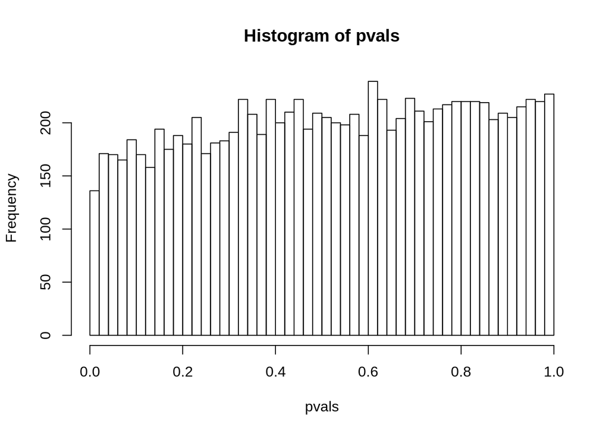

```r
control_population <- rnorm(100,20,3)
sample_size <- 12
pvals <- replicate(10000,{
        control_sample <-sample(control_population,sample_size)
        experiment_sample <- sample(control_population,sample_size)
        t.test(control_sample,experiment_sample)$p.val
})
hist(pvals,breaks=40)
```

## High false positive rate when performing thousands of tests

First we prepare the data set.

```r
# load dataset
library(leukemiasEset)
data(leukemiasEset)

# Select only ALL and NoL data
idx <- which(pData(leukemiasEset)$LeukemiaType %in% c("ALL","NoL"))
leukemiasEset <- leukemiasEset[,idx]
# Drop levels, so that there will still be only 2 levels in column "LeukemiaType"
pData(leukemiasEset)$LeukemiaType <- droplevels(pData(leukemiasEset)$LeukemiaType)

dim(leukemiasEset)
```

```
## Features  Samples
##    20172       24
```

For every gene, we can ask whether its expression level is significantly different between ALL patients and healthy people.

```r
idx_healthy <- which(pData(leukemiasEset)$LeukemiaType =="NoL")
idx_ALL <- which(pData(leukemiasEset)$LeukemiaType =="ALL")
pvals <- apply(exprs(leukemiasEset),1,function(this_row){
        t.test(this_row[idx_healthy],this_row[idx_ALL])$p.value
})
sum(pvals<0.05)
```

```
## [1] 7332
```

What?? 7332 genes are differentially expressed?? Actually no. Quite a lot is false positive. We can try the same analysis with a completely random data with no differential analysis at all.

```r
set.seed(1)
m <- nrow(exprs(leukemiasEset))
n <- ncol(exprs(leukemiasEset))
randomData <- matrix(rnorm(n*m),m,n)
nullpvals <- apply(randomData,1,function(this_row){
        t.test(this_row[idx_healthy],this_row[idx_ALL])$p.value
})
sum(nullpvals<0.05)
```

```
## [1] 986
```

Notice, we have 20172 genes in total. 20172*0.05=1009, not far from the number of false positive: 986. This is not a coincidence. When null is true, p value is exactly false positive rate.

## Monte Carlo simulation for a more complicated case

This is to say, there is $S$ true positive, $V$ false positive (type I error), $m_1-S$ false negative (type II error). Let’s define the truth.

```r
alpha <- 0.05 # false positive rate for a sigle hypothesis
sample_size <- 12
m <- 20172 # total number of genes
m1 <- 2000 # around 10% genes are significantly DE
m0 <- m-m1 # m0 genes are not DE

set.seed(1)
population_ne <- rnorm(100,mean=20,sd=3) # normal expressed genes
population_de <- rnorm(100,mean=23,sd=3) # differentially expressed genes
null_hypothesis <- c(rep(TRUE,m0),rep(FALSE,m1))
dat_ALL <- t(replicate(m,sample(population_ne,sample_size)))
dat_NoL_ne <- t(replicate(m0,sample(population_ne,sample_size)))
dat_NoL_de <- t(replicate(m1,sample(population_de,sample_size)))
dat_NoL <- rbind(dat_NoL_ne,dat_NoL_de)
dat <- cbind(dat_ALL,dat_NoL)
```

This is our simulated dataset. For rows where null_hypothesis is false, we add 3 to the right half of the matrix. Let’s see how many DE genes we can find using simple t-test.

```r
calls <- apply(dat,1,function(this_row){
        # this_row[1:12] records ALL data, this_row[13:24] records NoL data
        ifelse(t.test(this_row[1:12],this_row[13:24])$p.val<alpha,"Call significant", "Not call significant")
})
table(calls)
```

```
## calls
##     Call significant Not call significant
##                 1778                18394
```

```r
table(calls,null_hypothesis)
```

```
##                       null_hypothesis
## calls                  FALSE  TRUE
##   Call significant      1120   658
##   Not call significant   880 17514
```

Since the sampling process may generate different samples, $V$ and $S$ are all random variables.

## Family-wise error rate (FWER)

The FWER is the probability of making at least one type I error in all hypothesis testing.
$$FWER=Pr(V\geq1)$$
Or
$$FWER=1-Pr(V=0)$$

## Bonferroni Correction

We can reduce $V$ by rejecting hypotheses at a more strict level. Instead of rejecting hypothesis $i$ when $p_i<\alpha$, Bonferroni Correction require that we reject hypothesis when $p_i<\frac{\alpha}{m}$. Let’s try.

```r
m <- 20172 # number of hypotheses
calls <- apply(dat,1,function(this_row){
        # this_row[1:12] records ALL data, this_row[13:24] records NoL data
        ifelse(t.test(this_row[1:12],this_row[13:24])$p.val<alpha/m,"Call significant", "Not call significant")
})
table(calls)
```

```
## calls
## Not call significant
##                20172
```

```r
table(calls,null_hypothesis)
```

```
##                       null_hypothesis
## calls                  FALSE  TRUE
##   Not call significant  2000 18172
```

Mathematically FWER is controlled: there is no false positive, but at the expense of huge false negative. All of the 2000 DE genes are not called significant. We need a FWER control method that is less strick.

## False discovery rate (FDR)

Instead, we can focus on $Q=V/R$, i.e. among all the genes we called significant, what proportion is false positive? NOtice, $Q$, the proportion of false positive, is a random variable ranged from $0$ to $1$. We can simulate data to investigate the distribution of $Q$. Let’s keep assume that we call gene $i$ significant when $p_i<0.05$.

Besides,Function `rowttests()` calculates p value in a single step. We can try.

```r
library(genefilter)
group <- factor(c(rep("ALL",12),rep("NoL",12)))
calls <- rowttests(dat,group)
head(calls)
```

```
##     statistic          dm   p.value
## 1 -1.36340571 -1.39167981 0.1865454
## 2 -1.09311339 -1.46106604 0.2861695
## 3  0.80198415  1.09246743 0.4311402
## 4 -0.42840682 -0.45321483 0.6725202
## 5 -0.87831941 -0.99276526 0.3892625
## 6 -0.02371807 -0.02554083 0.9812913
```

The simulation starts now:

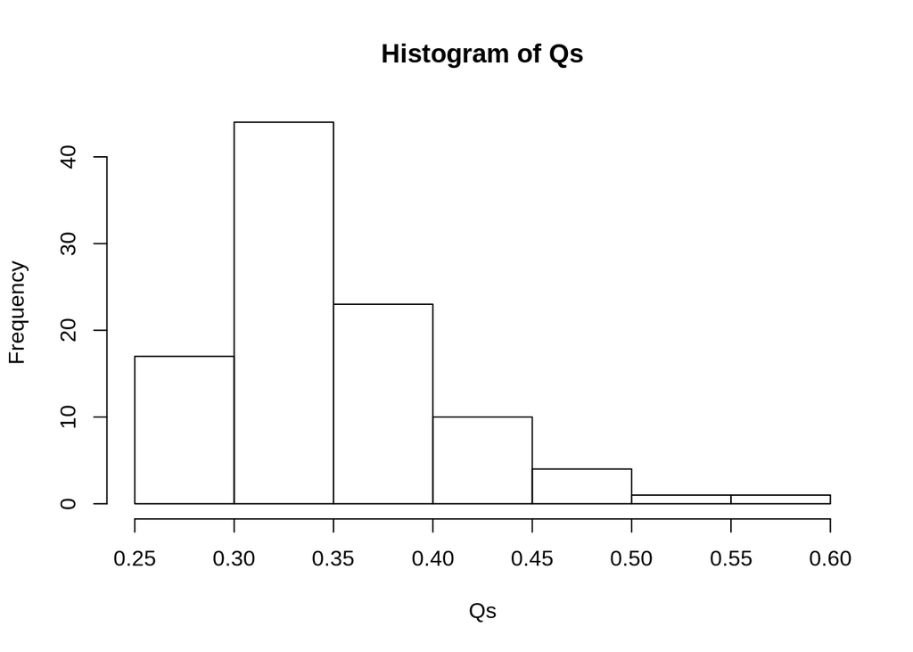

```r
alpha <- 0.05 # false positive rate for a sigle hypothesis
sample_size <- 12
m <- 20172 # total number of genes
m1 <- 2000 # around 10% genes are significantly DE
m0 <- m-m1 # m0 genes are not DE
null_hypothesis <- c(rep(TRUE,m0),rep(FALSE,m1))

simulated_data <- function(){
  population_ne <- rnorm(100,mean=20,sd=3) # normal expressed genes
  population_de <- rnorm(100,mean=23,sd=3) # differentially expressed genes
  dat_ALL <- t(replicate(m,sample(population_ne,sample_size)))
  dat_NoL_ne <- t(replicate(m0,sample(population_ne,sample_size)))
  dat_NoL_de <- t(replicate(m1,sample(population_de,sample_size)))
  dat_NoL <- rbind(dat_NoL_ne,dat_NoL_de)
  cbind(dat_ALL,dat_NoL)
}

B <- 100
Qs <- replicate(B,{
  pvals <- rowttests(simulated_data(),group)$p.value
  R <- sum(pvals<alpha)
  V <- length(which(pvals<alpha & null_hypothesis==TRUE))
  V/R
})
hist(Qs)
```

```r
FDR <- mean(Qs)
FDR
```

```
## [1] 0.3498224
```

So on average, among 10 genes we called significant, 3-4 are actually not significant. This is very high false positive rate. Why? Let’s see p value.

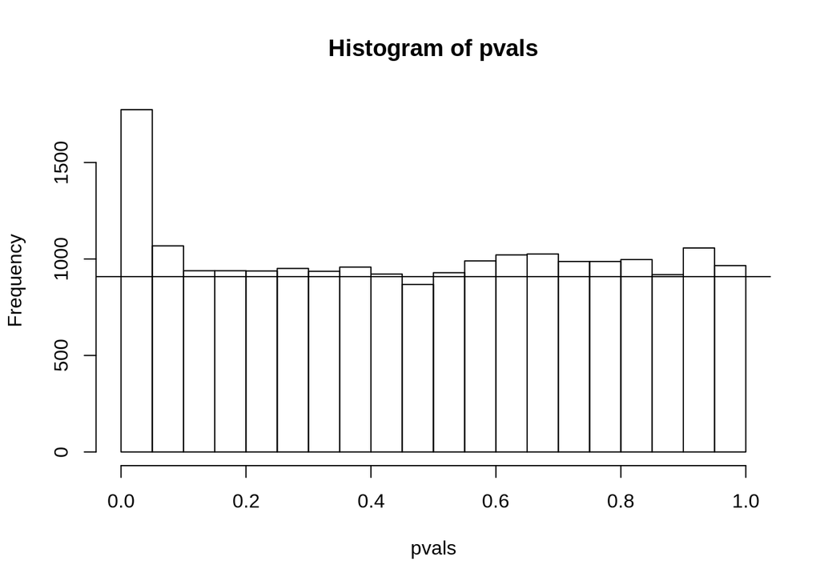

```r
pvals <- rowttests(simulated_data(),group)$p.value
hist(pvals,breaks=seq(0,1,0.05))
abline(h=m0/20)
```

The horizontal line signifies the distribution of p values when all nulls are true. The leftmost bar is what we call significant when $\alpha=0.05$. Around 50% of the bar lies under then line, this supports that the fact tha FDR is high.

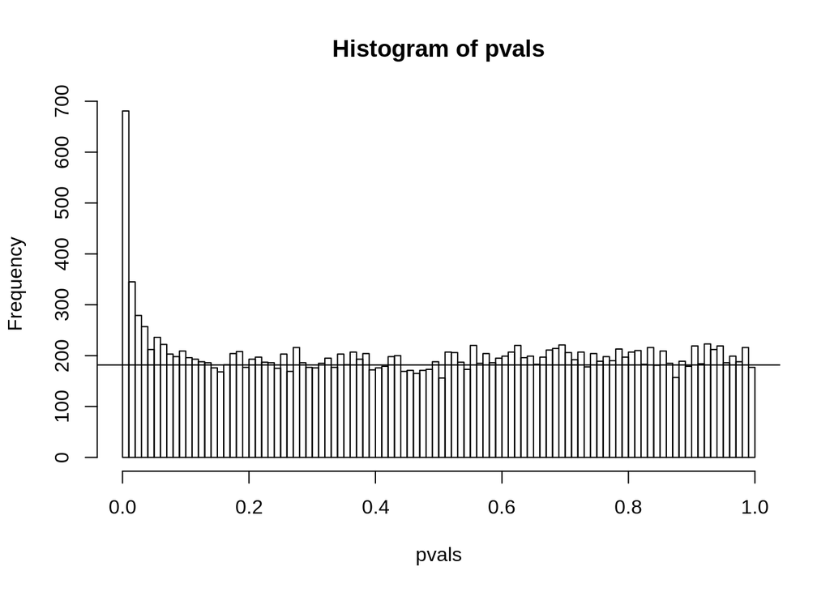

```r
hist(pvals,breaks=seq(0,1,0.01))
abline(h=m0/100)
```

The horizontal line signifies the distribution of p values when all nulls are true. The leftmost bar is what we call significant when $\alpha=0.01$.  
Now we can try to develop a procedure to control FDR.

## Benjamini-Hochberg

Benjaminini-Hockberg procedure require us first order the p values in increasing order.

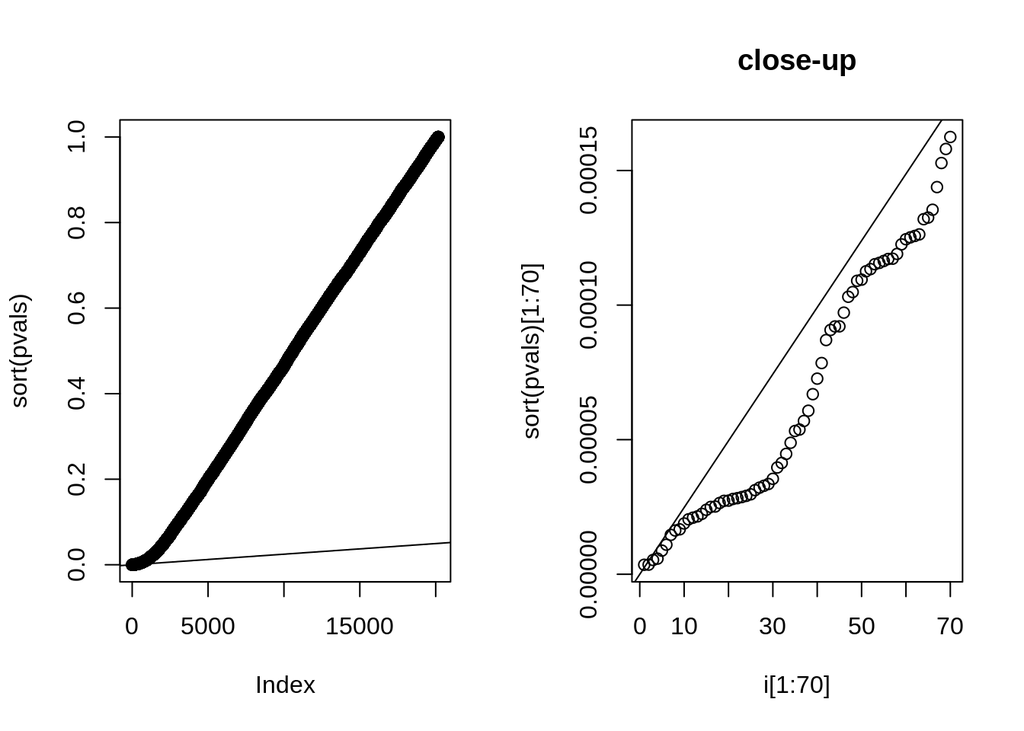

```r
library(genefilter)
alpha <- 0.05
set.seed(3)
dat <- simulated_data()
pvals <- rowttests(dat,group)$p.value
par(mfrow=c(1,2))
plot(sort(pvals))
i <- seq(along=pvals)
abline(0,i/m*alpha)
# close up image
plot(i[1:70],sort(pvals)[1:70],main="close-up")
abline(0,i/m*alpha)
```

```r
k <- max(which(sort(pvals)<i/m*alpha))
k
```

```
## [1] 97
```

Finally we reject hypothesis with p value smaller or equal to $p_{(k)}$

```r
cutoff <- sort(pvals)[k]
cutoff
```

```
## [1] 0.000237844
```

How good is this cutoff? Can we really control FDR below 0.05 using this cutoff?

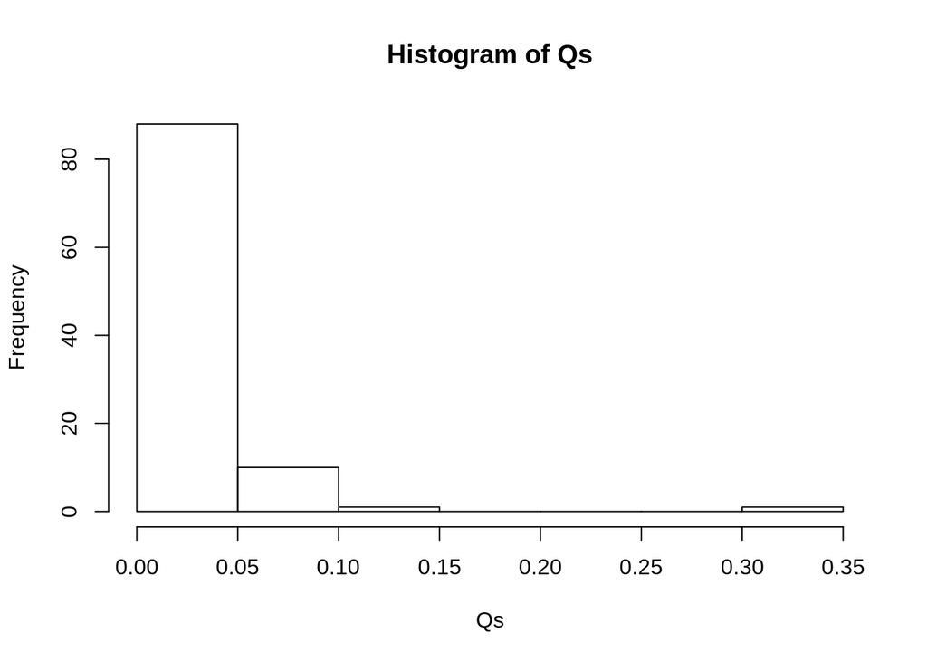

```r
B <- 100
Qs <- replicate(B,{
  pvals <- rowttests(simulated_data(),group)$p.value
  R <- sum(pvals<cutoff)
  V <- length(which(pvals<cutoff & null_hypothesis==TRUE))
  V/R
})
hist(Qs)
```

```r
FDR <- mean(Qs)
print(FDR)
```

```
## [1] 0.02791144
```

Cool! Now FDR<0.05.

## Function `p.adjust()`

We can sense that each cutoff p value corresponds to an expected proportion of false discoveries amongst the rejected hypotheses. . Function `p.adjust()` calculate the FDR corresponding to each p value

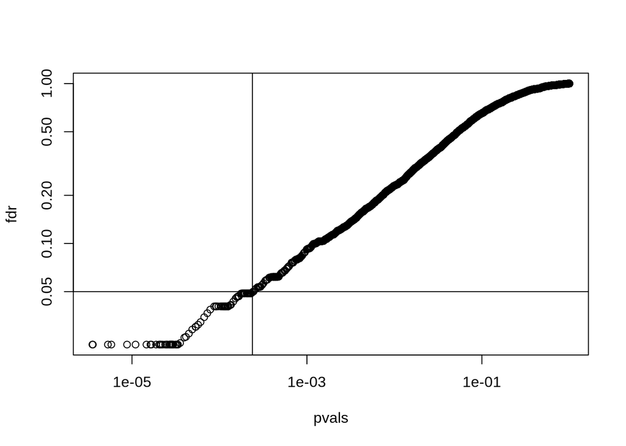

```r
fdr <- p.adjust(pvals,method="fdr")
plot(pvals,fdr,log="xy")
abline(h=alpha,v=cutoff)
```

Only the genes at left down corner is selected, so the frd is controlled below 0.05.